# LBasic-exDE

A Basic Model for Immature Mosquito Population Dynamics

David Smith

2022-10-28

$\uparrow$ Library || Aquatic Ecology

## -

Here, we update the `basic` model for larval dynamics, which first appeared as *Mosquito Population Regulation and Larval Source Management in Heterogeneous Environments* by Smith *et al* [1]. The same model also appears elsewhere [2,3].

Here, we want to look at the equations with a slightly more complex formulation:

$$\dot L = \eta - (\psi e^{-\xi L} + \phi + \Psi L^\sigma) L.$$
The basic elements are:

- Hatched eggs are laid at the rate $\eta(t)$
- The per-capita mortality rates of adult mosquitoes are $\phi + \Psi L^\sigma$
- Adults emerge at the rate $\alpha = \psi e^{-\xi L} L$, where we get equations equivalent to Smith *et al* by setting $\xi=0.$

The previous versions of this model set $\xi=0$

**Notes:**

- Setting $\phi = 0$ and $\sigma=1$, we get a very common form of the model (up to some minor differences) used by the Imperial model and VCOM [4,5], where $1/\Psi$ is interpreted as the carrying capacity.

## Steady State

An important feature of the modified equations is that productivity ($\alpha$) is not a monotonic increasing function of eggs laid $\eta$:

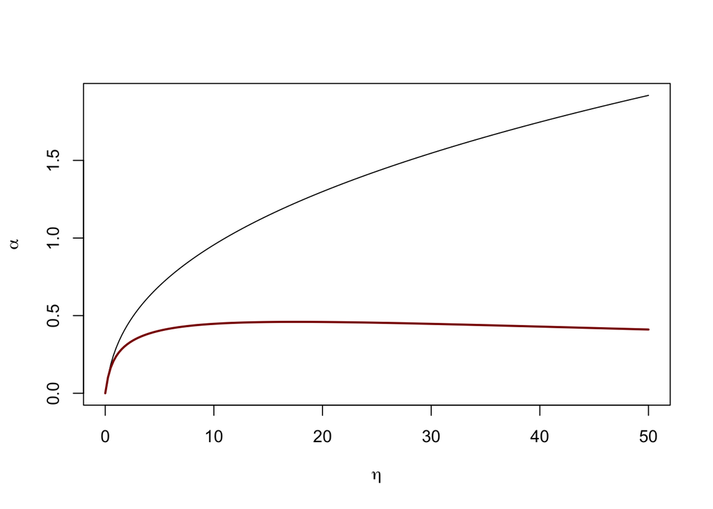

## Refs

1.

Smith DL, Perkins TA, Tusting LS, Scott TW, Lindsay SW. Mosquito Population Regulation and Larval Source Management in Heterogeneous Environments. PLOS ONE. 2013;8: e71247. doi:10.1371/journal.pone.0071247

2.

Brady OJ, Godfray HCJ, Tatem AJ, Gething PW, Cohen JM, McKenzie FE, et al. Adult vector control, mosquito ecology and malaria transmission. International Health. 2015;7: 121–129. doi:10.1093/inthealth/ihv010

3.

Wu SL, Henry JM, Citron DT, Ssebuliba DM, Nsumba JN, C HMS, et al. Spatial dynamics of malaria transmission. PLOS Computational Biology. 2023;19: e1010684. doi:10.1371/journal.pcbi.1010684

4.

White MT, Griffin JT, Churcher TS, Ferguson NM, Basáñez M-G, Ghani AC. Modelling the impact of vector control interventions on Anopheles gambiae population dynamics. Parasit Vectors. 2011;4: 153. Available: http://www.biomedcentral.com/content/pdf/1756-3305-4-153.pdf

5.

Kiware SS, Chitnis N, Tatarsky A, Wu S, Castellanos HMS, Gosling R, et al. Attacking the mosquito on multiple fronts: Insights from the Vector Control Optimization Model (VCOM) for malaria elimination. PLoS One. 2017;12: e0187680. doi:10.1371/journal.pone.0187680